# STA108 Project 1 Final Report

Su-Ting Tan, Jennifer Ngo, Mary Bangloy

# Introduction

The dataset that we will be analyzing in our project is demographic information on 440 selected counties in the United States. In the dataset, each county is coordinated with an identification number that represents a county. In the second line, there are the county names and state abbreviations that correspond to each county. There are a total of 14 variables included in the dataset ranging from total population, number of active physicians, total personal income, and more. The data were recorded between the years of 1990 and 1992. The purpose of this project is to compare how certain variables are related to each and how strong their relationships are. First, we will select a certain variable from our CDI data set and regress it against three other different variables. We will analyze the regression functions and how their slopes, intercepts, and MSE vary. Analysis of certain variables will be narrowed down within each region (NE, NC, S, and W) and we will compare the regression functions and MSE between them. Furthermore, we will analyze the $R^2$ of each predictor variable and see how much they play a role in the variability of other variables.We’ll even further analyze the confidence interval to estimate the $\beta_1$ so that we can compare the regression lines. Lastly, we will obtain a residual plot and normal probability plot for the predictor variables to determine whether the linear regression model is appropriate or not.

# Part I: Fitting regression models

## Project 1.43

1. Regress the number of active physicians in turn on each of the three predictor variables. State the estimated regression functions.

Let $Y$ be the number of active physicians in a CDI, $X_1$ be the Total Population:
$$\widehat{Y}=-110.635+0.002795X_1$$

Let $Y$ be the number of active physicians in a CDI, $X_2$ be the number of Hospital Beds: :
$$\widehat{Y}=-95.932218+0.74312X_2$$

Let $Y$ be the number of active physicians in a CDI, $X_3$ be the Total Personal Income :
$$\widehat{Y}=-48.39485+013170X_3$$

……

2. Plot the three estimated regression functions and data on separate graphs. Does a linear regression relation appear to provide a good fit for each of the three predictor variables?

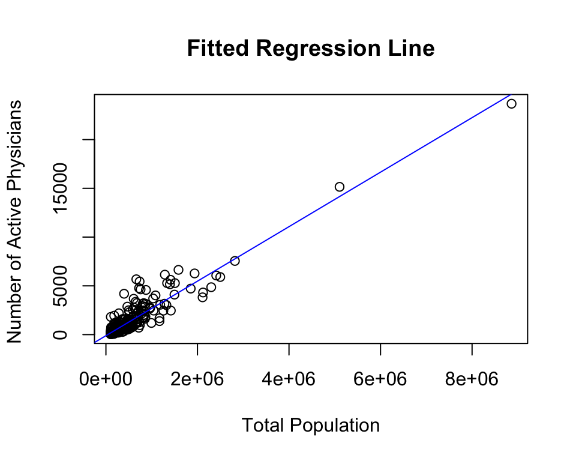

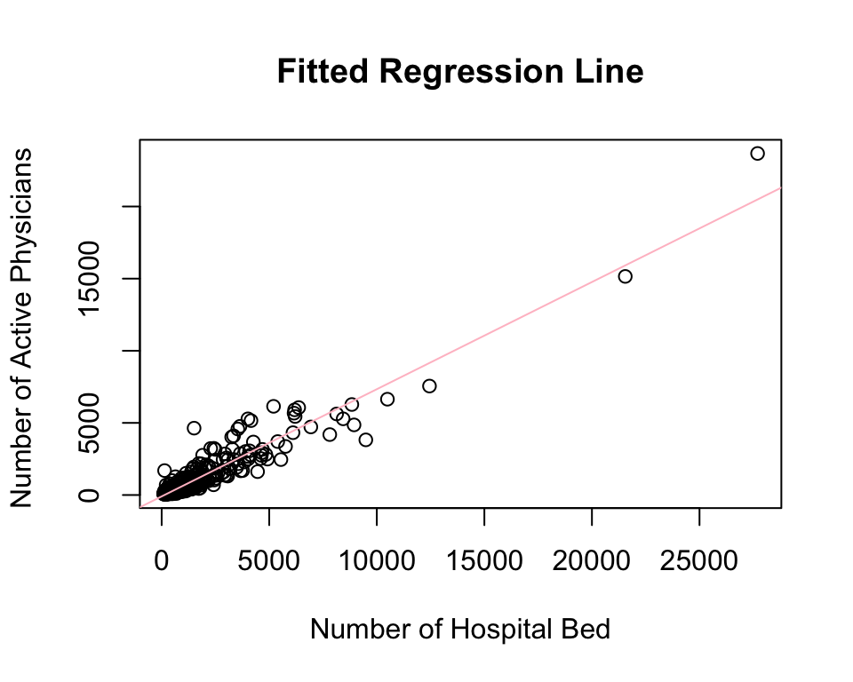

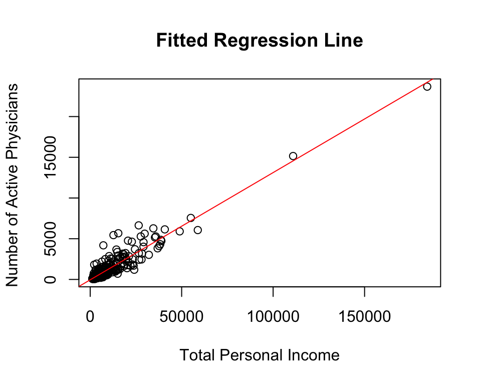

c.) Calculate MSE for each of the the three predictor variables. Which predictor variable leads to the smallest variability around the fitted regression line?

MSE for Total Population: 372203.50491

MSE for Total Personal Income : 324539.39367

## Projects 1.44

a.) For each geographic region, regress per capita income in a CDI (Y) against the percentage of individuals in a county having at east a bachelors degree (X). Assume that first-order regression model (1.1) is appropriate for each region. State the estimated regression functions.

For Region 1 (NE), let $Y$ be the per capita income , $X_1$ be percent bachelor’s degree:
$$\widehat{Y}=9223.8+522.2X_1$$

For Region 2 (NC), let $Y$ be the per capita income , $X_2$ be percent bachelor’s degree:
$$\widehat{Y}= 13581.4+238.7X_2$$

For Region 3 (S), let $Y$ be the per capita income , $X_3$ be percent bachelor’s degree:
$$\widehat{Y}= 10529.8+330.6X_3$$

For Region 4 (W), let $Y$ be the per capita income , $X_4$ be percent bachelor’s degree:
$$\widehat{Y}= 8615.1+440.3X_4$$

b.) Are the estimated regression functions similar for the four regions? Discuss.

```
## [1] 7335008
```

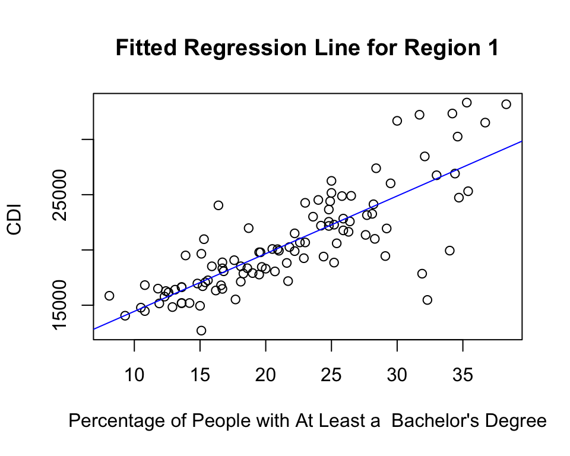

```
##
## Call:
## lm(formula = Y_NC ~ X_NC)
##
## Residuals:
##     Min      1Q  Median      3Q     Max
## -7167.6  -915.4   105.6   886.6  6159.2
##
## Coefficients:
##             Estimate Std. Error t value Pr(>|t|)
## (Intercept) 13581.41     575.14  23.614  < 2e-16 ***
## X_NC          238.67      27.23   8.765 3.34e-14 ***
## ---
## Signif. codes:  0 '***' 0.001 '**' 0.01 '*' 0.05 '.' 0.1 ' ' 1
##
## Residual standard error: 2100 on 106 degrees of freedom
## Multiple R-squared:  0.4202, Adjusted R-squared:  0.4147
## F-statistic: 76.83 on 1 and 106 DF,  p-value: 3.344e-14
```

```
## [1] 4411341
```

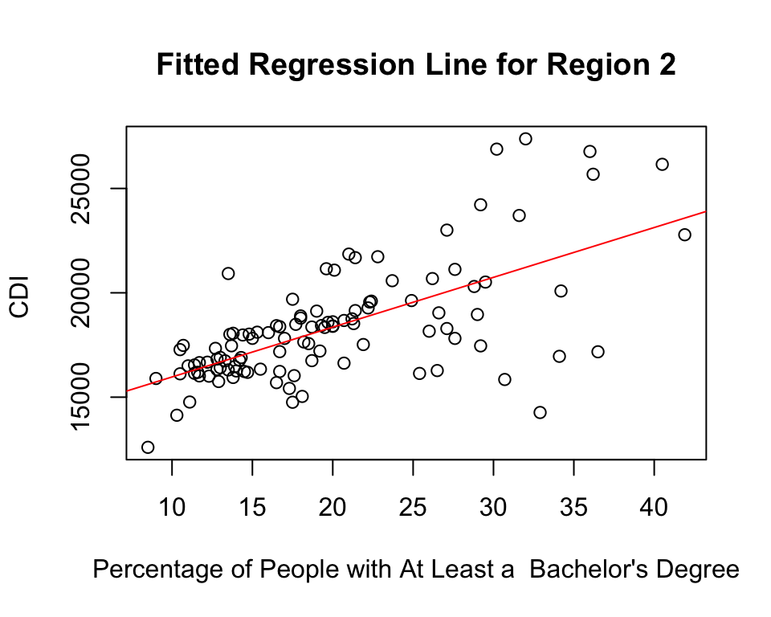

```
##
## Call:
## lm(formula = Y_S ~ X_S)
##
## Residuals:
##     Min      1Q  Median      3Q     Max
## -9724.7 -1362.8   114.9  1255.6  9883.8
##
## Coefficients:
##             Estimate Std. Error t value Pr(>|t|)
## (Intercept) 10529.79     612.48   17.19   <2e-16 ***
## X_S           330.61      27.13   12.19   <2e-16 ***
## ---
## Signif. codes:  0 '***' 0.001 '**' 0.01 '*' 0.05 '.' 0.1 ' ' 1
##
## Residual standard error: 2734 on 150 degrees of freedom
## Multiple R-squared:  0.4975, Adjusted R-squared:  0.4941
## F-statistic: 148.5 on 1 and 150 DF,  p-value: < 2.2e-16
```

```
## [1] 7474349
```

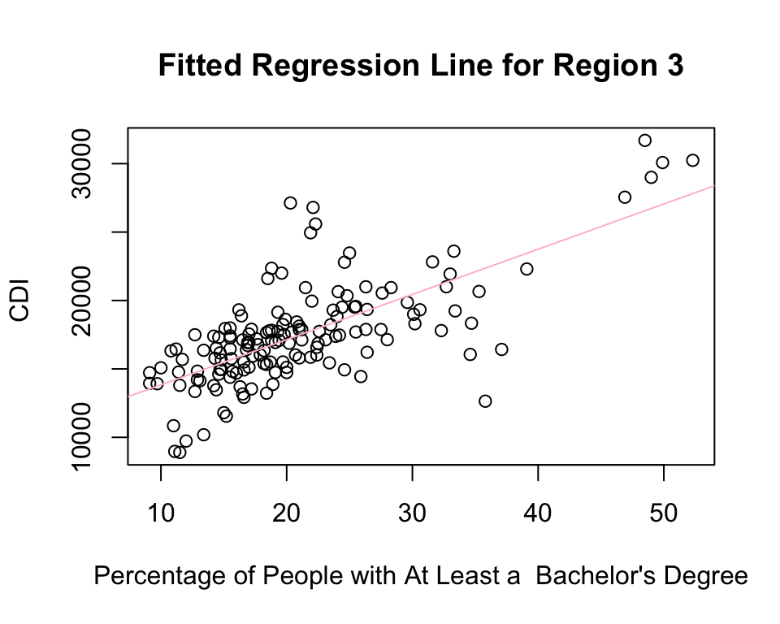

```
##
## Call:
## lm(formula = Y_W ~ X_W)
##
## Residuals:
##     Min      1Q  Median      3Q     Max
## -8684.3 -1477.3   191.7  1557.8  9552.1
##
## Coefficients:
##             Estimate Std. Error t value Pr(>|t|)
## (Intercept)  8615.05    1052.20   8.188 5.24e-12 ***
## X_W           440.32      45.37   9.705 6.86e-15 ***
## ---
## Signif. codes:  0 '***' 0.001 '**' 0.01 '*' 0.05 '.' 0.1 ' ' 1
##
## Residual standard error: 2866 on 75 degrees of freedom
## Multiple R-squared:  0.5567, Adjusted R-squared:  0.5508
## F-statistic: 94.19 on 1 and 75 DF,  p-value: 6.856e-15
```

```
## [1] 8214318
```

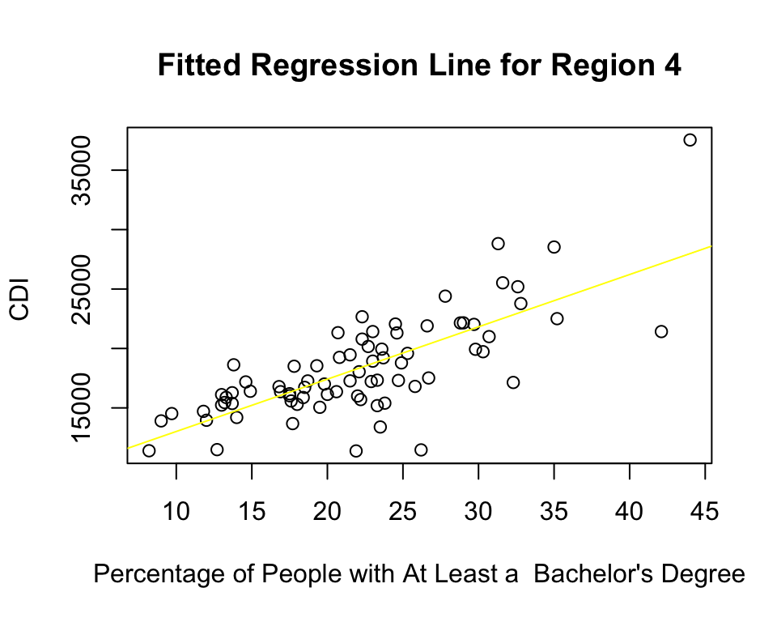

C.) Calculate MSE for each region. Is the variability around the fitted regression line approximately the same for the four regions? Discuss.

MSE for Region 1 (NE): 7,335,008

MSE for Region 2(NC): 4,411,341

MSE for Region 3 (S): 7,474,349

MSE for Region 4 (W):8,214,318

```
## [1] 7335008
```

```
##
## Call:
## lm(formula = Y_NC ~ X_NC)
##
## Residuals:
##     Min      1Q  Median      3Q     Max
## -7167.6  -915.4   105.6   886.6  6159.2
##
## Coefficients:
##             Estimate Std. Error t value Pr(>|t|)
## (Intercept) 13581.41     575.14  23.614  < 2e-16 ***
## X_NC          238.67      27.23   8.765 3.34e-14 ***
## ---
## Signif. codes:  0 '***' 0.001 '**' 0.01 '*' 0.05 '.' 0.1 ' ' 1
##
## Residual standard error: 2100 on 106 degrees of freedom
## Multiple R-squared:  0.4202, Adjusted R-squared:  0.4147
## F-statistic: 76.83 on 1 and 106 DF,  p-value: 3.344e-14
```

```
## [1] 4411341
```

```
##
## Call:
## lm(formula = Y_S ~ X_S)
##
## Residuals:
##     Min      1Q  Median      3Q     Max
## -9724.7 -1362.8   114.9  1255.6  9883.8
##
## Coefficients:
##             Estimate Std. Error t value Pr(>|t|)
## (Intercept) 10529.79     612.48   17.19   <2e-16 ***
## X_S           330.61      27.13   12.19   <2e-16 ***
## ---
## Signif. codes:  0 '***' 0.001 '**' 0.01 '*' 0.05 '.' 0.1 ' ' 1
##
## Residual standard error: 2734 on 150 degrees of freedom
## Multiple R-squared:  0.4975, Adjusted R-squared:  0.4941
## F-statistic: 148.5 on 1 and 150 DF,  p-value: < 2.2e-16
```

```
## [1] 7474349
```

```
##
## Call:
## lm(formula = Y_W ~ X_W)
##
## Residuals:
##     Min      1Q  Median      3Q     Max
## -8684.3 -1477.3   191.7  1557.8  9552.1
##
## Coefficients:
##             Estimate Std. Error t value Pr(>|t|)
## (Intercept)  8615.05    1052.20   8.188 5.24e-12 ***
## X_W           440.32      45.37   9.705 6.86e-15 ***
## ---
## Signif. codes:  0 '***' 0.001 '**' 0.01 '*' 0.05 '.' 0.1 ' ' 1
##
## Residual standard error: 2866 on 75 degrees of freedom
## Multiple R-squared:  0.5567, Adjusted R-squared:  0.5508
## F-statistic: 94.19 on 1 and 75 DF,  p-value: 6.856e-15
```

```
## [1] 8214318
```

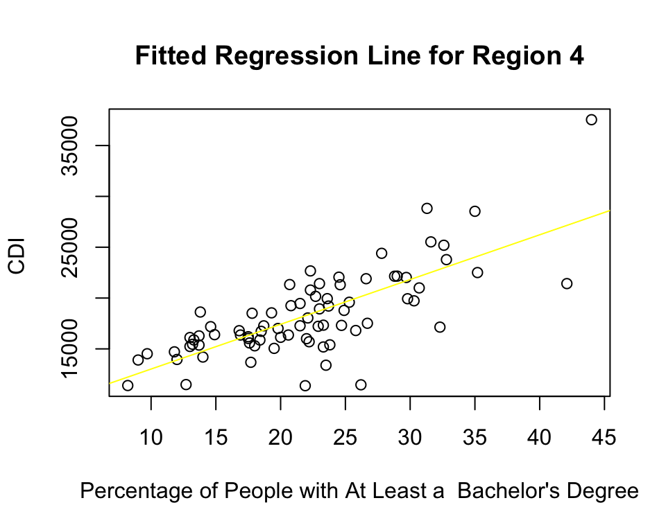

# Part II: Measuring linear associations

```
## [1] 0.8840674
```

```
## [1] 0.9033826
```

```
## [1] 0.8989137
```

Which predictor variable accounts for the largest reduction in the variability in the number of active physicians?

The number of hospital beds is the predictor variable that accounts for the largest reduction in the variability in the number of active physicians. $R^2$ = 0.9033826. It is the greatest $R^2$ value out of the three: total population, number of hospital beds, and total personal income.

# Part III: Inference about regression parameters

## Project 2.63

Refer to the CDI data set in Appendix C.2 and Project 1.44. Obtain a separate interval estimate of $\beta_1$ for each region. Use a 90 percent confidence coefficient in each case. Do the regression lines for the different regions appear to have similar slopes?

```
## [1] 460.5177 583.8000
```

We are 90% confident that the slope of the regression model that relates the individuals in region 1 (NE) with a bachelor’s degree and their per capita income will lie between 460.5177 and 583.8000.

```
## [1] 193.4858 283.8530
```

We are 90% confident that the slope of the regression model that relates the individuals in region 2 (NC) with a bachelor’s degree and their per capita income will lie between 193.4858 and 283.8530.

```
## [1] 285.7076 375.5158
```

We are 90% confident that the slope of the regression model that relates the individuals in region 3 (S) with a bachelor’s degree and their per capita income will lie between 285.7076 and 375.5158.

```
## [1] 364.7585 515.8729
```

We are 90% confident that the slope of the regression model that relates the individuals in region 4 (W) with a bachelor’s degree and their per capita income will lie between 364.7585 and 515.8729.

Carry out the analysis of variance (ANOVA) for each regression model and state the results of the F-tests. What do you conclude in each case?

| Source | Df | SS | MS | F_value | p_value |
| --- | --- | --- | --- | --- | --- |
| Regression | 1 | 1450517671 | 1450517671 | 197.7527 | 0 |
| Error | 101 | 740835765 | 7335008 |  |  |
| Total | 102 | 2191353436 |  |  |  |

| Source | Df | SS | MS | F_value | p_value |
| --- | --- | --- | --- | --- | --- |
| Regression | 1 | 338907694 | 338907694 | 76.82646 | 0 |
| Error | 106 | 467602149 | 4411341 |  |  |
| Total | 107 | 806509843 |  |  |  |

| Source | Df | SS | MS | F_value | p_value |
| --- | --- | --- | --- | --- | --- |
| Regression | 1 | 1109873245 | 1109873245 | 148.491 | 0 |
| Error | 150 | 1121152411 | 7474349 |  |  |
| Total | 151 | 2231025656 |  |  |  |

| Source | df | SS | MS | F_value | p_value |
| --- | --- | --- | --- | --- | --- |
| Regression | 1 | 773745787 | 773745787 | 94.19477 | 0 |
| Error | 75 | 616073841 | 8214318 |  |  |
| Total | 76 | 1389819629 |  |  |  |

For Region 1:

```
## [1] 2.755868
```

$H_0: \beta_1=0,\: H_A: \beta_1≠0$

Conclusion: At a significance level of α = .1, we observe that the given coefficient is useful for the regression model and that there is a linear association. There is a significant statistical relationship between per capita income and the percentage of individuals that have at least a bachelors degree in Region 1.

For Region 2:

```
## [1] 2.753462
```

$H_0: \beta_1=0,\: H_A: \beta_1≠0$

Conclusion: At a significance level of α = .1, we observe that the given coefficient is useful for the regression model and that there is a linear association. There is a significant statistical relationship between per capita income and the percentage of individuals that have at least a bachelors degree in Region 2.

For Region 3:

```
## [1] 2.739275
```

$H_0: \beta_1=0,\: H_A: \beta_1≠0$

Conclusion: At a significance level of α = .1, we observe that the given coefficient is useful for the regression model and that there is a linear association. There is a significant statistical relationship between per capita income and the percentage of individuals that have at least a bachelors degree in Region 3.

For Region 4:

```
## [1] 2.773642
```

$H_0: \beta_1=0,\: H_A: \beta_1≠0$

Conclusion: At a significance level of α = .1, we observe that the given coefficient is useful for the regression model and that there is a linear association. There is a significant statistical relationship between per capita income and the percentage of individuals that have at least a bachelors degree in Region 4.

# Part IV: Regression diagnostics

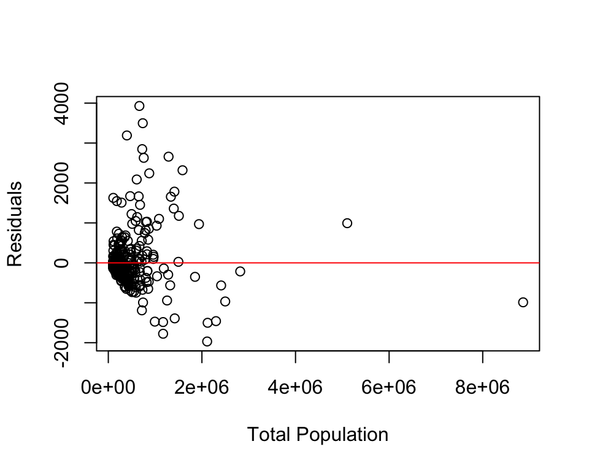

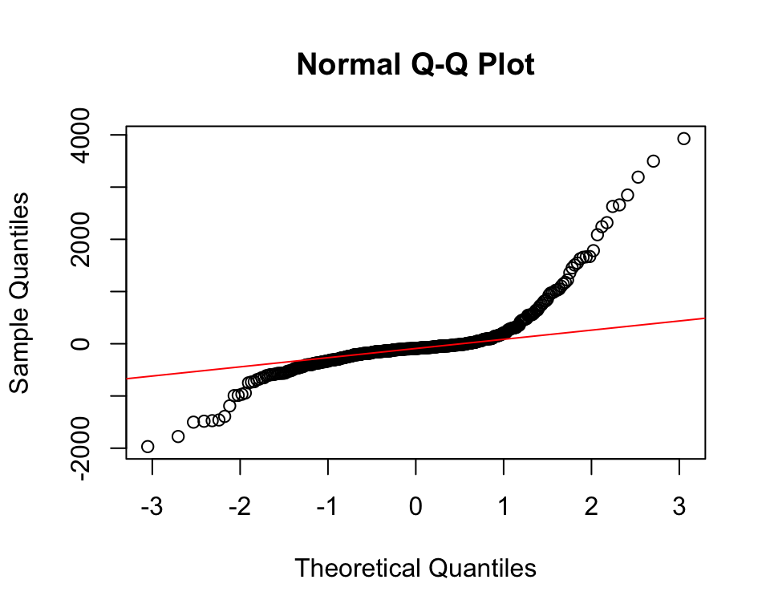

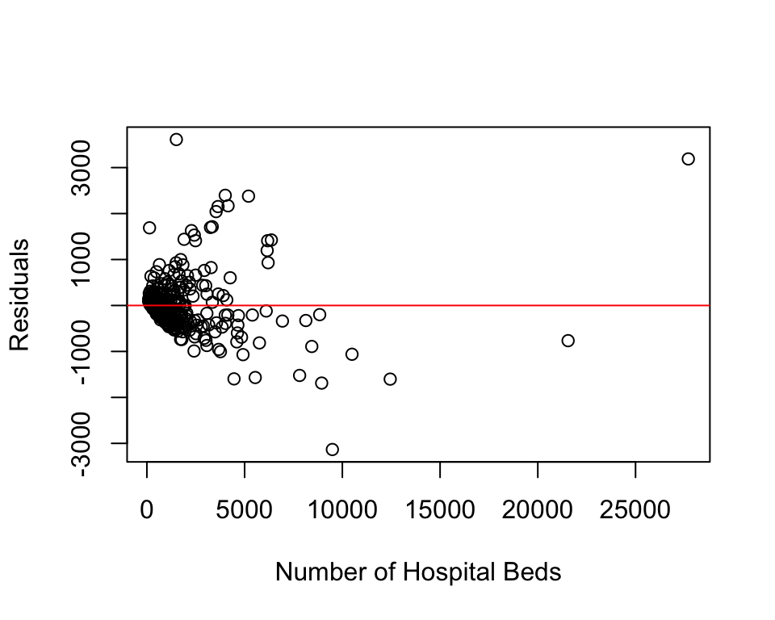

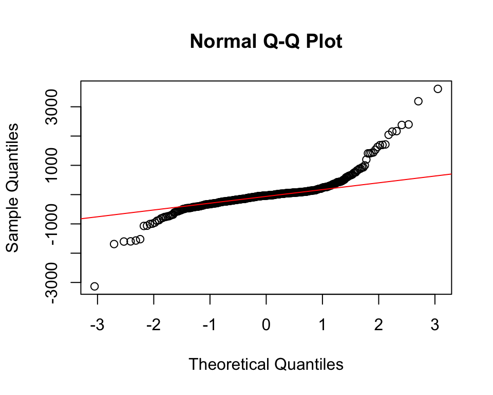

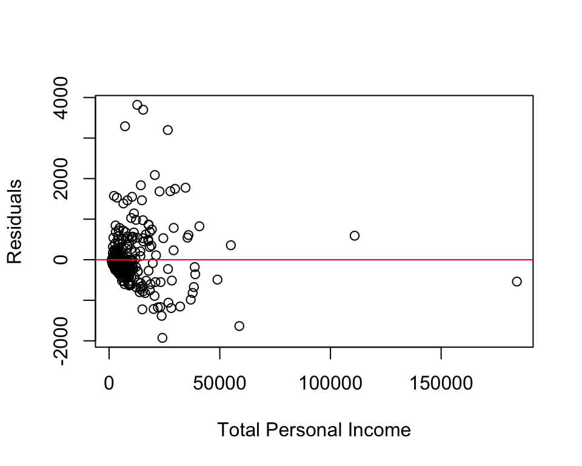

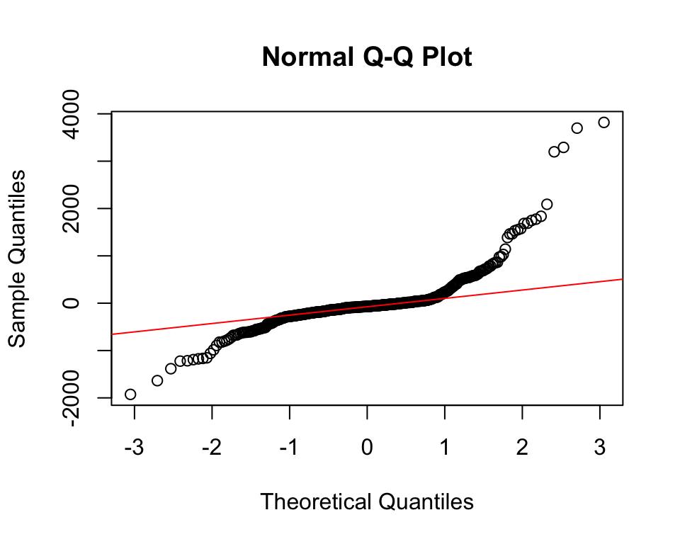

The residual plots indicate the presence of outliers. There are two noticeable outliers. Points are clustered towards the left end of the residual plot where total population, number of hospital beds, and total personal income are at lower numbers. The distributions of the error terms are symmetrical, but with heavy tails. There are higher probabilities in the tails than in a normal distribution. Both tails correspond to left-skewed and right-skewed distributions. This is because our data includes more extreme values than we would expect from a normal distribution. The linear regression model (2.1) is not more appropriate in one case than in others. Our fitted regression lines imply linear association between X and Y.

# Part V: Discussion

90% variation in the number of active physicians is explained by the predictor variable, number of hospital beds. This is the largest reduction in the variability in the number of active physicians. When we constructed confidence intervals for our 4 regions, we saw that the intervals were different for each region, which means that the slopes of the regression lines are pretty different for each region. When we constructed F-tests, which is a test to see if there is any statistical relationship between the two variables, we saw for each of the regions there is any relationship between per capita income and the percentage of individuals that have at least a bachelor’s degree. This means that having a bachelor’s degree can affect the income you will be getting.

Based on our residual plots, we notice that total population, number of hospital beds, and total personal income cluster at lower numbers. This means that most U.S. counties are of fewer populations, with less hospital beds, and lower personal incomes. The number of active physicians in these counties varied—having less or more than expected in relation to these variables. Our Normal Q-Q plot indicates that our data includes more extreme values, or outliers, in our data.

Some potential problems that we can see with our dataset is that when we plot the residual and Normal Q-Q plots, there seems to be a great amount of extreme values in our dataset. Having these outliers can affect the results that we have obtained from doing our multiple tests. To improve the linear regression model, we can remove some outliers. It is harder to make conclusions based on the graphs—Fitted Regression Line, Residuals against predictor X, and Normal Q-Q Plot—because of them. These outliers have a greater population, higher personal incomes, more physicians, and more hospital beds. We should focus on the counties who are low income, with lower populations and not enough medical resources. Once we remove the outliers, we can cater our attention to these counties by analyzing a more tailored representation of them.

A way to improve the regression model is by transforming the variables on a logarithmic scale. When you analyze a linear regression of a set of data, they might not look like there isn’t a linear relationship with the X and Y component when they are plotted against each other. Transforming the data to a logarithmic scale linearizes the relationship between the X and Y values, allowing us to conduct a linear regression analysis.

# Appendix

```r
knitr::opts_chunk$set(
    error = FALSE,
    message = FALSE,
    warning = FALSE,
    echo = FALSE, # hide all R codes!!
    fig.width=5, fig.height=4,#set figure size
    fig.align='center',#center plot
    options(knitr.kable.NA = ''), #do not print NA in knitr table
    tidy = FALSE #add line breaks in R codes
)
data1 = read.table("/Users/marybangloy/Desktop/STA 108/Project 1/CDI.txt")
Y= data1[,8] # number of physicians
X1=data1[,5] #total pop
X2=data1[,9] #number of hospital bed
X3=data1[,16]#total personal income
n1=length(X1)
n2=length(X2)
n3=length(X3)

fit1 = lm(Y~X1)
# summary(fit1) #Yhat=-110.635+0.002795X

#regress for number of hospital bed
fit2 = lm(Y~X2)
# summary(fit2) #Yhat=-95.93218+0.74312X

#regress for total personal income
fit3 = lm(Y~X3)
# summary(fit3) #Yhat=-48.39485+0.13170
#Fitted line
plot(X1,Y, xlab="Total Population",ylab="Number of Active Physicians ", main = "Fitted Regression Line")
abline(fit1, col="blue")
#Fitted line
plot(X2,Y, xlab="Number of Hospital Bed",ylab="Number of Active Physicians ", main = "Fitted Regression Line")
abline(fit2, col="pink")
#Fitted line
plot(X3,Y, xlab="Total Personal Income",ylab="Number of Active Physicians ", main = "Fitted Regression Line")
abline(fit3, col="red")

#total pop
b1hat1 =t(X1-mean(X1))%*%(Y-mean(Y))/sum((X1-mean(X1))^2)
b0hat1 = mean(Y) - b1hat1*mean(X1)
fit.y1 = b0hat1 + b1hat1*X1
mse1 = 1/(n1-2)*sum((Y - fit.y1)^2) #MSE=372203.50491

#hospital bed
b1hat2 = sum((X2-mean(X2))*(Y-mean(Y)))/sum((X2-mean(X2))^2)
b0hat2 = mean(Y) - b1hat2*mean(X2)
fit.y2 = b0hat2 + b1hat2*X2
mse2 = 1/(n2-2)*sum((Y - fit.y2)^2) #MSE=31091.88354

#total income
b1hat3 = sum((X3-mean(X3))*(Y-mean(Y)))/sum((X3-mean(X3))^2)
b0hat3 = mean(Y) - b1hat3*mean(X3)
fit.y3 = b0hat3 + b1hat3*X3
mse3 = 1/(n3-2)*sum((Y - fit.y3)^2) #MSE=324539.39367


regions= data1[,17]
# regions
# NE
# regions==1
NE=data1[regions==1,]
# head(NE)
# lm(V15~V12,data=NE)
# Yhat=9223.8+522.2X
# NC
# lm(V15~V12,data=data1[regions==2,]) #Yhat=13581.4+238.7X
# S
# lm(V15~V12,data=data1[regions==3,])#Yhat=10529.8+330.6X
# W
# lm(V15~V12,data=data1[regions==4,])#Yhat=8615.1+440.3X

NE= subset(data1,regions==1)
Y_NE= NE[,15]
X_NE= NE[,12]
n=length(X_NE)
fitNE=lm(Y_NE~X_NE)
y_hatNE=fitNE$fitted.values
SSENE= sum((Y_NE-y_hatNE)^2)
MSENE= SSENE/(n-2)
MSENE
plot(V15~V12,data=data1[regions==1,], xlab="Percentage of People with At Least a  Bachelor's Degree",ylab="CDI ", main = "Fitted Regression Line for Region 1")
abline(fitNE, col="blue")


NC= subset(data1,regions == 2)
Y_NC =NC[,15]
X_NC= NC[,12]
n= length(X_NC)
fit_NC=lm(Y_NC~X_NC)
summary(fit_NC)
y_hatNC=fit_NC$fitted.values
SSE_NC= sum((Y_NC-y_hatNC)^2)
MSE_NC= SSE_NC/(n-2)
MSE_NC

plot(V15~V12,data=data1[regions==2,], xlab="Percentage of People with At Least a  Bachelor's Degree",ylab="CDI ", main = "Fitted Regression Line for Region 2")
abline(fit_NC, col="red")



S= subset(data1,regions == 3)
Y_S= S[,15]
X_S= S[,12]
n= length(X_S)
fit_S=lm(Y_S~X_S)
summary(fit_S)
y_hatS= fit_S$fitted.values
SSE_S= sum((Y_S-y_hatS)^2)
MSE_S= SSE_S/(n-2)
MSE_S
plot(V15~V12,data=data1[regions==3,], xlab="Percentage of People with At Least a  Bachelor's Degree",ylab="CDI ", main = "Fitted Regression Line for Region 3")
abline(fit_S, col="pink")

W= subset(data1,regions == 4)
Y_W= W[,15]
X_W= W[,12]
n= length(X_W)
fit_W=lm(Y_W~X_W)
summary(fit_W)
y_hatW= fit_W$fitted.values
SSE_W= sum((Y_W-y_hatW)^2)
MSE_W= SSE_W/(n-2)
MSE_W
plot(V15~V12,data=data1[regions==4,], xlab="Percentage of People with At Least a  Bachelor's Degree",ylab="CDI ", main = "Fitted Regression Line for Region 4")
abline(fit_W, col="yellow")


NE= subset(data1,regions==1)
Y_NE= NE[,15]
X_NE= NE[,12]
n=length(X_NE)
fitNE=lm(Y_NE~X_NE)
y_hatNE=fitNE$fitted.values
SSENE= sum((Y_NE-y_hatNE)^2)
MSENE= SSENE/(n-2)
MSENE

NC= subset(data1,regions == 2)
Y_NC =NC[,15]
X_NC= NC[,12]
n= length(X_NC)
fit_NC=lm(Y_NC~X_NC)
summary(fit_NC)
y_hatNC=fit_NC$fitted.values
SSE_NC= sum((Y_NC-y_hatNC)^2)
MSE_NC= SSE_NC/(n-2)
MSE_NC


S= subset(data1,regions == 3)
Y_S= S[,15]
X_S= S[,12]
n= length(X_S)
fit_S=lm(Y_S~X_S)
summary(fit_S)
y_hatS= fit_S$fitted.values
SSE_S= sum((Y_S-y_hatS)^2)
MSE_S= SSE_S/(n-2)
MSE_S


W= subset(data1,regions == 4)
Y_W= W[,15]
X_W= W[,12]
n= length(X_W)
fit_W=lm(Y_W~X_W)
summary(fit_W)
y_hatW= fit_W$fitted.values
SSE_W= sum((Y_W-y_hatW)^2)
MSE_W= SSE_W/(n-2)
MSE_W
plot(V15~V12,data=data1[regions==4,], xlab="Percentage of People with At Least a  Bachelor's Degree",ylab="CDI ", main = "Fitted Regression Line for Region 4")
abline(fit_W, col="yellow")

data1 = read.table("/Users/marybangloy/Desktop/STA 108/Project 1/CDI.txt")
Y = data1[,8] # number of active physicians

totalPop = data1[,5] # total population
fit1 = lm(Y~totalPop)
summary(fit1)$r.squared

hospitalBeds = data1[,9] # number of hospital beds
fit2 = lm(Y~hospitalBeds)
summary(fit2)$r.squared

personalIncome = data1[,16] # total personal income
fit3 = lm(Y~personalIncome)
summary(fit3)$r.squared
cdi_data = read.table("/Users/marybangloy/Desktop/STA 108/Project 1/CDI.txt")

## REGION 1
regions=cdi_data[,17]
#regions
n1 = dim(subset(cdi_data, V17 == 1))[1]

#regions==2
NE=cdi_data[regions==1,]
#NE

fit_r1 = lm(V15~V12, data=NE)
#summary(fit_r2)

#Get least square estimates:
#fit=lm(V15~V12, data=NE)
b0hat = fit_r1$coefficients[[1]]
b1hat = fit_r1$coefficients[[2]]

#MSE
MSE = summary(fit_r1)$sigma^2

se.b0hat = summary(fit_r1)$coefficients[1,"Std. Error"]
se.b1hat = summary(fit_r1)$coefficients[2,"Std. Error"]

#Test statistics:
alpha = 0.1
p = 1-alpha/2
t.value = (b1hat-1)/se.b1hat
critical.value= qt(p, df = n1 - 2)
#abs(t.value) > critical.value
#Reject H0 if get TRUE

#confidence interval
lb.b1hat = b1hat - critical.value*se.b1hat
ub.b1hat = b1hat + critical.value*se.b1hat
c(lb.b1hat, ub.b1hat)
## REGION 2

regions=cdi_data[,17]
#regions
n2 = dim(subset(cdi_data, V17 == 2))[1]

#regions==2
NC=cdi_data[regions==2,]
#NC

fit_r2 = lm(V15~V12, data=NC)
#summary(fit_r2)

#Get least square estimates:
#fit=lm(V15~V12, data=NE)
b0hat = fit_r2$coefficients[[1]]
b1hat = fit_r2$coefficients[[2]]

#MSE
MSE = summary(fit_r2)$sigma^2

se.b0hat = summary(fit_r2)$coefficients[1,"Std. Error"]
se.b1hat = summary(fit_r2)$coefficients[2,"Std. Error"]

#Test statistics:
alpha = 0.1
p = 1-alpha/2
t.value = (b1hat-1)/se.b1hat
critical.value= qt(p, df = n2 - 2)
#abs(t.value) > critical.value
#Reject H0 if get TRUE

#confidence interval
lb.b1hat = b1hat - critical.value*se.b1hat
ub.b1hat = b1hat + critical.value*se.b1hat
c(lb.b1hat, ub.b1hat)
##Region 3
#regions==3
r3=cdi_data[regions==3,]
#r3
regions=cdi_data[,17]
#regions
n3 = dim(subset(cdi_data, V17 == 3))[1]

#regions==3
S=cdi_data[regions==3,]
#S

fit_r3 = lm(V15~V12, data=S)
#summary(fit_r3)

#Get least square estimates:
b0hat = fit_r3$coefficients[[1]]
b1hat = fit_r3$coefficients[[2]]

#MSE
MSE = summary(fit_r3)$sigma^2

se.b0hat = summary(fit_r3)$coefficients[1,"Std. Error"]
se.b1hat = summary(fit_r3)$coefficients[2,"Std. Error"]

#Test statistics:
alpha = 0.1
p = 1-alpha/2
t.value = (b1hat-1)/se.b1hat
critical.value= qt(p, df = n3 - 2)
#abs(t.value) > critical.value
#Reject H0 if get TRUE

#confidence interval
lb.b1hat = b1hat - critical.value*se.b1hat
ub.b1hat = b1hat + critical.value*se.b1hat
c(lb.b1hat, ub.b1hat)
## REGION 4

r4=cdi_data[regions==4,]
#r4
regions=cdi_data[,17]
#regions
n4 = dim(subset(cdi_data, V17 == 4))[1]

#regions==4
W=cdi_data[regions==4,]
#W

fit_r4 = lm(V15~V12, data=W)
#summary(fit_r4)

#Get least square estimates:
b0hat = fit_r4$coefficients[[1]]
b1hat = fit_r4$coefficients[[2]]

#MSE
MSE = summary(fit_r4)$sigma^2

se.b0hat = summary(fit_r4)$coefficients[1,"Std. Error"]
se.b1hat = summary(fit_r4)$coefficients[2,"Std. Error"]

#Test statistics:
alpha = 0.1
p = 1-alpha/2
t.value = (b1hat-1)/se.b1hat
critical.value= qt(p, df = n4 - 2)
#abs(t.value) > critical.value
#Reject H0 if get TRUE

#confidence interval
lb.b1hat = b1hat - critical.value*se.b1hat
ub.b1hat = b1hat + critical.value*se.b1hat
c(lb.b1hat, ub.b1hat)
#ANOVA
regions=cdi_data[,17]
#regions

r1=cdi_data[regions==1,]

data1 = read.table("/Users/marybangloy/Desktop/STA 108/Project 1/CDI.txt")
Y = r1$V15
X = r1$V12
n = length(Y)

fit = lm(Y~X)

y_hat = fit$fitted.values
SSTO = sum((Y-mean(Y))^2)
SSE = sum((Y-y_hat)^2)
SSR = sum((y_hat-mean(Y))^2)
MSR = SSR/(1)
MSE = SSE/(n-2)
Fstatistic = MSR/MSE
pvalue = pf(Fstatistic, 1, n-2, lower.tail = F)
result=data.frame(Source=c("Regression", "Error", "Total"),
                  Df=c(1, n-2,n-1), SS=c(SSR, SSE, SSTO),
                  MS=c(MSR, MSE,NA), F_value=c(Fstatistic,NA,NA),
                  p_value=c(pvalue,NA,NA))
library(knitr)
kable(result)
#REGION 2
#regions==2
r2=cdi_data[regions==2,]

data1 = read.table("/Users/marybangloy/Desktop/STA 108/Project 1/CDI.txt")
Y = r2$V15
X = r2$V12
n = length(Y)

fit = lm(Y~X)

y_hat = fit$fitted.values
SSTO = sum((Y-mean(Y))^2)
SSE = sum((Y-y_hat)^2)
SSR = sum((y_hat-mean(Y))^2)
MSR = SSR/(1)
MSE = SSE/(n-2)
Fstatistic = MSR/MSE
pvalue = pf(Fstatistic, 1, n-2, lower.tail = F)
result=data.frame(Source=c("Regression", "Error", "Total"),
                  Df=c(1, n-2,n-1), SS=c(SSR, SSE, SSTO),
                  MS=c(MSR, MSE,NA), F_value=c(Fstatistic,NA,NA),
                  p_value=c(pvalue,NA,NA))
library(knitr)
kable(result)
#REGION 3
r3=cdi_data[regions==3,]

data1 = read.table("/Users/marybangloy/Desktop/STA 108/Project 1/CDI.txt")
Y = r3$V15
X = r3$V12
n = length(Y)

fit = lm(Y~X)

y_hat = fit$fitted.values
SSTO = sum((Y-mean(Y))^2)
SSE = sum((Y-y_hat)^2)
SSR = sum((y_hat-mean(Y))^2)
MSR = SSR/(1)
MSE = SSE/(n-2)
Fstatistic = MSR/MSE
pvalue = pf(Fstatistic, 1, n-2, lower.tail = F)
result=data.frame(Source=c("Regression", "Error", "Total"),
                  Df=c(1, n-2,n-1), SS=c(SSR, SSE, SSTO),
                  MS=c(MSR, MSE,NA), F_value=c(Fstatistic,NA,NA),
                  p_value=c(pvalue,NA,NA))
library(knitr)
kable(result)
#REGION 4
r4=cdi_data[regions==4,]

data1 = read.table("/Users/marybangloy/Desktop/STA 108/Project 1/CDI.txt")
Y = r4$V15
X = r4$V12
n = length(Y)

fit = lm(Y~X)

y_hat = fit$fitted.values
SSTO = sum((Y-mean(Y))^2)
SSE = sum((Y-y_hat)^2)
SSR = sum((y_hat-mean(Y))^2)
MSR = SSR/(1)
MSE = SSE/(n-2)
Fstatistic = MSR/MSE
pvalue = pf(Fstatistic, 1, n-2, lower.tail = F)
result=data.frame(Source=c("Regression", "Error", "Total"),
                  df=c(1, n-2,n-1), SS=c(SSR, SSE, SSTO),
                  MS=c(MSR, MSE,NA), F_value=c(Fstatistic,NA,NA),
                  p_value=c(pvalue,NA,NA))
library(knitr)
kable(result)
alpha = 0.1
FCritVal_r1 = qf(1-alpha,1,101) #2.755868, n-2=103-2
FCritVal_r1
alpha = 0.1
FCritVal_r2 = qf(1-alpha,1,106) #2.753462, n-2=108-2
FCritVal_r2
alpha = 0.1
FCritVal_r3 = qf(1-alpha,1,150) #2.739275, n-2=152-2
FCritVal_r3
alpha = 0.1
FCritVal_r4 = qf(1-alpha,1,75) #2.773642, n-2=77-2
FCritVal_r4
# Total Population: Residual plot against X
residualsX1 = fit1$residuals
plot(x = X1, y = residualsX1, xlab = "Total Population", ylab = "Residuals")
abline(h = 0, col = "red")

# Total Population: Normal Probability Q-Q Plot
qqnorm(residualsX1)
qqline(residualsX1, col= "red")
# Number of Hospital Beds: Residual plot against X
residualsX2 = fit2$residuals
plot(x = X2, y = residualsX2, xlab = "Number of Hospital Beds", ylab = "Residuals")
abline(h = 0, col = "red")

# Number of Hospital Beds: Normal Probability Q-Q Plot
qqnorm(residualsX2)
qqline(residualsX2, col= "red")
# Total Personal Income: Residual plot against X
residualsX3 = fit3$residuals
plot(x = X3, y = residualsX3, xlab = "Total Personal Income", ylab = "Residuals")
abline(h = 0, col = "red")

# Total Personal Income: Normal Probability Q-Q Plot
qqnorm(residualsX3)
qqline(residualsX3, col= "red")
```